> **Tip**: Welcome to the Investigate a Dataset project! You will find tips in quoted sections like this to help organize your approach to your investigation. Before submitting your project, it will be a good idea to go back through your report and remove these sections to make the presentation of your work as tidy as possible. First things first, you might want to double-click this Markdown cell and change the title so that it reflects your dataset and investigation.

# Project: TMDB - Movies DataSet

- Introduction
- Data Wrangling
- Exploratory Data Analysis
- Conclusions

## Introduction

> **Tip**: In this section of the report, provide a brief introduction to the dataset you've selected for analysis. At the end of this section, describe the questions that you plan on exploring over the course of the report. Try to build your report around the analysis of at least one dependent variable and three independent variables. If you're not sure what questions to ask, then make sure you familiarize yourself with the dataset, its variables and the dataset context for ideas of what to explore.

> If you haven't yet selected and downloaded your data, make sure you do that first before coming back here. In order to work with the data in this workspace, you also need to upload it to the workspace. To do so, click on the jupyter icon in the upper left to be taken back to the workspace directory. There should be an 'Upload' button in the upper right that will let you add your data file(s) to the workspace. You can then click on the .ipynb file name to come back here.

```python
import pandas as pd
import numpy as np
import matplotlib.pyplot as plt
import seaborn as sns
% matplotlib inline
from datetime import datetime
```

## Data Wrangling

> **Tip**: In this section of the report, you will load in the data, check for cleanliness, and then trim and clean your dataset for analysis. Make sure that you document your steps carefully and justify your cleaning decisions.

### General Properties

```python
# Load your data and print out a few lines. Perform operations to inspect data
#   types and look for instances of missing or possibly errant data.
df_movie = pd.read_csv("tmdb-movies.csv")
df_movie.head(4)
```

|  | id | imdb_id | popularity | budget | revenue | original_title | cast | homepage | director | tagline | ... | overview | runtime | genres | production_companies | release_date | vote_count | vote_average | release_year | budget_adj | revenue_adj |
| --- | --- | --- | --- | --- | --- | --- | --- | --- | --- | --- | --- | --- | --- | --- | --- | --- | --- | --- | --- | --- | --- |
| 0 | 135397 | tt0369610 | 32.985763 | 150000000 | 1513528810 | Jurassic World | Chris Pratt\|Bryce Dallas Howard\|Irrfan Khan\|Vi... | http://www.jurassicworld.com/ | Colin Trevorrow | The park is open. | ... | Twenty-two years after the events of Jurassic ... | 124 | Action\|Adventure\|Science Fiction\|Thriller | Universal Studios\|Amblin Entertainment\|Legenda... | 6/9/15 | 5562 | 6.5 | 2015 | 1.379999e+08 | 1.392446e+09 |
| 1 | 76341 | tt1392190 | 28.419936 | 150000000 | 378436354 | Mad Max: Fury Road | Tom Hardy\|Charlize Theron\|Hugh Keays-Byrne\|Nic... | http://www.madmaxmovie.com/ | George Miller | What a Lovely Day. | ... | An apocalyptic story set in the furthest reach... | 120 | Action\|Adventure\|Science Fiction\|Thriller | Village Roadshow Pictures\|Kennedy Miller Produ... | 5/13/15 | 6185 | 7.1 | 2015 | 1.379999e+08 | 3.481613e+08 |
| 2 | 262500 | tt2908446 | 13.112507 | 110000000 | 295238201 | Insurgent | Shailene Woodley\|Theo James\|Kate Winslet\|Ansel... | http://www.thedivergentseries.movie/#insurgent | Robert Schwentke | One Choice Can Destroy You | ... | Beatrice Prior must confront her inner demons ... | 119 | Adventure\|Science Fiction\|Thriller | Summit Entertainment\|Mandeville Films\|Red Wago... | 3/18/15 | 2480 | 6.3 | 2015 | 1.012000e+08 | 2.716190e+08 |
| 3 | 140607 | tt2488496 | 11.173104 | 200000000 | 2068178225 | Star Wars: The Force Awakens | Harrison Ford\|Mark Hamill\|Carrie Fisher\|Adam D... | http://www.starwars.com/films/star-wars-episod... | J.J. Abrams | Every generation has a story. | ... | Thirty years after defeating the Galactic Empi... | 136 | Action\|Adventure\|Science Fiction\|Fantasy | Lucasfilm\|Truenorth Productions\|Bad Robot | 12/15/15 | 5292 | 7.5 | 2015 | 1.839999e+08 | 1.902723e+09 |

4 rows × 21 columns

```python
df_movie.shape
```

```
(10866, 21)
```

```python
df_movie.describe()
```

|  | id | popularity | budget | revenue | runtime | vote_count | vote_average | release_year | budget_adj | revenue_adj |
| --- | --- | --- | --- | --- | --- | --- | --- | --- | --- | --- |
| count | 10866.000000 | 10866.000000 | 1.086600e+04 | 1.086600e+04 | 10866.000000 | 10866.000000 | 10866.000000 | 10866.000000 | 1.086600e+04 | 1.086600e+04 |
| mean | 66064.177434 | 0.646441 | 1.462570e+07 | 3.982332e+07 | 102.070863 | 217.389748 | 5.974922 | 2001.322658 | 1.755104e+07 | 5.136436e+07 |
| std | 92130.136561 | 1.000185 | 3.091321e+07 | 1.170035e+08 | 31.381405 | 575.619058 | 0.935142 | 12.812941 | 3.430616e+07 | 1.446325e+08 |
| min | 5.000000 | 0.000065 | 0.000000e+00 | 0.000000e+00 | 0.000000 | 10.000000 | 1.500000 | 1960.000000 | 0.000000e+00 | 0.000000e+00 |
| 25% | 10596.250000 | 0.207583 | 0.000000e+00 | 0.000000e+00 | 90.000000 | 17.000000 | 5.400000 | 1995.000000 | 0.000000e+00 | 0.000000e+00 |
| 50% | 20669.000000 | 0.383856 | 0.000000e+00 | 0.000000e+00 | 99.000000 | 38.000000 | 6.000000 | 2006.000000 | 0.000000e+00 | 0.000000e+00 |
| 75% | 75610.000000 | 0.713817 | 1.500000e+07 | 2.400000e+07 | 111.000000 | 145.750000 | 6.600000 | 2011.000000 | 2.085325e+07 | 3.369710e+07 |
| max | 417859.000000 | 32.985763 | 4.250000e+08 | 2.781506e+09 | 900.000000 | 9767.000000 | 9.200000 | 2015.000000 | 4.250000e+08 | 2.827124e+09 |

```python
df_movie.info()
```

```
<class 'pandas.core.frame.DataFrame'>
RangeIndex: 10866 entries, 0 to 10865
Data columns (total 21 columns):
id                      10866 non-null int64
imdb_id                 10856 non-null object
popularity              10866 non-null float64
budget                  10866 non-null int64
revenue                 10866 non-null int64
original_title          10866 non-null object
cast                    10790 non-null object
homepage                2936 non-null object
director                10822 non-null object
tagline                 8042 non-null object
keywords                9373 non-null object
overview                10862 non-null object
runtime                 10866 non-null int64
genres                  10843 non-null object
production_companies    9836 non-null object
release_date            10866 non-null object
vote_count              10866 non-null int64
vote_average            10866 non-null float64
release_year            10866 non-null int64
budget_adj              10866 non-null float64
revenue_adj             10866 non-null float64
dtypes: float64(4), int64(6), object(11)
memory usage: 1.7+ MB
```

Hence we have some column which is not neccessary, we identify as "imdb_id","homepage","overview","budget_adj","revenue_Adj".so we will drop in data cleaning steps

```python
df_movie.head(1)
```

|  | id | imdb_id | popularity | budget | revenue | original_title | cast | homepage | director | tagline | ... | overview | runtime | genres | production_companies | release_date | vote_count | vote_average | release_year | budget_adj | revenue_adj |
| --- | --- | --- | --- | --- | --- | --- | --- | --- | --- | --- | --- | --- | --- | --- | --- | --- | --- | --- | --- | --- | --- |
| 0 | 135397 | tt0369610 | 32.985763 | 150000000 | 1513528810 | Jurassic World | Chris Pratt\|Bryce Dallas Howard\|Irrfan Khan\|Vi... | http://www.jurassicworld.com/ | Colin Trevorrow | The park is open. | ... | Twenty-two years after the events of Jurassic ... | 124 | Action\|Adventure\|Science Fiction\|Thriller | Universal Studios\|Amblin Entertainment\|Legenda... | 6/9/15 | 5562 | 6.5 | 2015 | 1.379999e+08 | 1.392446e+09 |

1 rows × 21 columns

```python
df_movie.isnull().sum()
```

```
id                         0
imdb_id                   10
popularity                 0
budget                     0
revenue                    0
original_title             0
cast                      76
homepage                7930
director                  44
tagline                 2824
keywords                1493
overview                   4
runtime                    0
genres                    23
production_companies    1030
release_date               0
vote_count                 0
vote_average               0
release_year               0
budget_adj                 0
revenue_adj                0
dtype: int64
```

```python
#we found out that 'budget','revenue' column have null and zero value. Now we have two options to solve null problem. one is drop the null value which is we are not going to use because this is too much rows to drop so we cant analysis like this
#We are going to use fill the row by zero.
df_budget = df_movie.groupby('budget').count()['id']

df_revenue = df_movie.groupby('revenue').count()['id']
df_budget.head(2), df_revenue.head(2)
```

```
(budget
 0    5696
 1       4
 Name: id, dtype: int64, revenue
 0    6016
 2       2
 Name: id, dtype: int64)
```

On above cell, there are 5696 and 6016 counts of 0 values for budget and revenue columns more than non zero values, which is a lot. If we would drop the all null rows it can corrupt our findings or results

```python
#In runtime column, there is small row which consists of null value so we can drop this row
df_runtime = df_movie.groupby('runtime').count()['id']
df_runtime.head(2)
```

```
runtime
0    31
2     5
Name: id, dtype: int64
```

Based on above result, there are few zero values in runtime columns, so we can drop it to clean the data

> **Tip**: You should *not* perform too many operations in each cell. Create cells freely to explore your data. One option that you can take with this project is to do a lot of explorations in an initial notebook. These don't have to be organized, but make sure you use enough comments to understand the purpose of each code cell. Then, after you're done with your analysis, create a duplicate notebook where you will trim the excess and organize your steps so that you have a flowing, cohesive report.

> **Tip**: Make sure that you keep your reader informed on the steps that you are taking in your investigation. Follow every code cell, or every set of related code cells, with a markdown cell to describe to the reader what was found in the preceding cell(s). Try to make it so that the reader can then understand what they will be seeing in the following cell(s).

- First we drop the uneccessary column

```python
df_movie.drop(['homepage','tagline','budget_adj','revenue_adj','imdb_id','overview'], axis=1, inplace=True)
```

```python
#we can check this above column has been drop
df_movie.head(2)
```

|  | id | popularity | budget | revenue | original_title | cast | director | keywords | runtime | genres | production_companies | release_date | vote_count | vote_average | release_year |
| --- | --- | --- | --- | --- | --- | --- | --- | --- | --- | --- | --- | --- | --- | --- | --- |
| 0 | 135397 | 32.985763 | 150000000 | 1513528810 | Jurassic World | Chris Pratt\|Bryce Dallas Howard\|Irrfan Khan\|Vi... | Colin Trevorrow | monster\|dna\|tyrannosaurus rex\|velociraptor\|island | 124 | Action\|Adventure\|Science Fiction\|Thriller | Universal Studios\|Amblin Entertainment\|Legenda... | 6/9/15 | 5562 | 6.5 | 2015 |
| 1 | 76341 | 28.419936 | 150000000 | 378436354 | Mad Max: Fury Road | Tom Hardy\|Charlize Theron\|Hugh Keays-Byrne\|Nic... | George Miller | future\|chase\|post-apocalyptic\|dystopia\|australia | 120 | Action\|Adventure\|Science Fiction\|Thriller | Village Roadshow Pictures\|Kennedy Miller Produ... | 5/13/15 | 6185 | 7.1 | 2015 |

```python
#Drop the duplicates
df_movie.shape
```

```
(10866, 15)
```

- Drop the duplicates from dataset

```python
df_movie.drop_duplicates(inplace=True)
```

```python
df_movie.shape
```

```
(10865, 15)
```

- Drop Null values with small amount of null
- We have small amount of null in cast,director,genres so we will drop it.

```python
#Drop Null values with small amount of null
#We have small amount of null in cast,director,genres so we will drop it.
df_movie.isnull().sum()
```

[output not shown]

```python
Null_column = ['cast','director','genres']
df_movie.dropna(subset=Null_column, how='any', inplace=True)
```

```python
df_movie.isnull().sum().any
```

```
<bound method Series.any of id                         0
popularity                 0
budget                     0
revenue                    0
original_title             0
cast                       0
director                   0
keywords                1425
runtime                    0
genres                     0
production_companies     959
release_date               0
vote_count                 0
vote_average               0
release_year               0
dtype: int64>
```

```python
#Now we have to replace Null values by zero
#then checked any null value is present or not
df_movie['budget'] = df_movie['budget'].replace(0, np.NaN)
df_movie['revenue'] = df_movie['revenue'].replace(0, np.NaN)
df_movie.info()
```

[output not shown]

```python
#Drop the runtime column's null values
df_revenue = df_movie.groupby('runtime').count()['id']
df_revenue.head(2)
```

```
runtime
0    31
2     5
Name: id, dtype: int64
```

```python
df_movie.query("runtime != 0", inplace=True)
df_movie.query("runtime == 0")
```

[output not shown]

## Exploratory Data Analysis

> **Tip**: Now that you've trimmed and cleaned your data, you're ready to move on to exploration. Compute statistics and create visualizations with the goal of addressing the research questions that you posed in the Introduction section. It is recommended that you be systematic with your approach. Look at one variable at a time, and then follow it up by looking at relationships between variables.

### Research Question 1 Movie with highest and lowest budget

```python
#make the function for max and min to find more answer for other column
def HighLow(x):
    Low_index = df_movie[x].idxmin()
    High_index = df_movie[x].idxmax()
    lowest = pd.DataFrame(df_movie.loc[Low_index,:])
    highest = pd.DataFrame(df_movie.loc[High_index,:])

    #Print the highest and lowest
    print("Highest " +  x +  " : ", df_movie["original_title"][High_index])
    print("Lowset " + x + " : ", df_movie["original_title"][Low_index])
    return pd.concat([highest,lowest], axis=1)


HighLow('budget')
```

```
Highest budget :  The Warrior's Way
Lowset budget :  Fear Clinic
```

[output not shown]

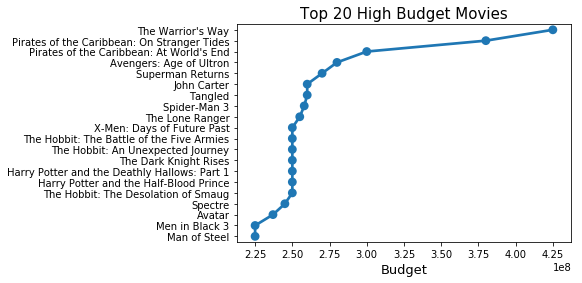

```python
data_budget = pd.DataFrame(df_movie['budget'].sort_values(ascending = False))
data_budget['original_title'] = df_movie['original_title']
data = list(map(str,(data_budget['original_title'])))

#extract top 20 movies
x = list(data[:20])
y = list(data_budget['budget'][:20])
axs = sns.pointplot(x=y,y=x)
sns.set(rc={'figure.figsize':(20,10)})
axs.set_title("Top 20 High Budget Movies",fontsize = 15)
axs.set_xlabel("Budget",fontsize = 13)
sns.set_style("darkgrid")
```

Based on above graph, we can see that 'The warrior way' is highest budget movie

### Research Question 2 : Movie with highest and lowest profit

```python
# we dont have Profit column so we will add new column
df_movie['profit'] = df_movie['revenue']  - df_movie['budget']
```

```python
#we made earlier munmax function we will use for this
HighLow('profit')
```

```
Highest profit :  Avatar
Lowset profit :  The Warrior's Way
```

|  | 1386 | 2244 |
| --- | --- | --- |
| id | 19995 | 46528 |
| popularity | 9.43277 | 0.25054 |
| budget | 2.37e+08 | 4.25e+08 |
| revenue | 2.78151e+09 | 1.10876e+07 |
| original_title | Avatar | The Warrior's Way |
| cast | Sam Worthington\|Zoe Saldana\|Sigourney Weaver\|S... | Kate Bosworth\|Jang Dong-gun\|Geoffrey Rush\|Dann... |
| director | James Cameron | Sngmoo Lee |
| keywords | culture clash\|future\|space war\|space colony\|so... | assassin\|small town\|revenge\|deception\|super speed |
| runtime | 162 | 100 |
| genres | Action\|Adventure\|Fantasy\|Science Fiction | Adventure\|Fantasy\|Action\|Western\|Thriller |
| production_companies | Ingenious Film Partners\|Twentieth Century Fox ... | Boram Entertainment Inc. |
| release_date | 12/10/09 | 12/2/10 |
| vote_count | 8458 | 74 |
| vote_average | 7.1 | 6.4 |
| release_year | 2009 | 2010 |
| profit | 2.54451e+09 | -4.13912e+08 |

The first column shows the highest profit made by a movie and second column shows the highest in loss movie in this dataset. It shows Avatar is also less budget movie than 'the Warrior's way'. and Avatar also have earned highest Profitable movie record.

```python
data_profit = pd.DataFrame(df_movie['profit'].sort_values(ascending = False))
data_profit['original_title'] = df_movie['original_title']
data = list(map(str,(data_profit['original_title'])))
data
#extract top 20 movies
x = list(data[:20])
y = list(data_profit['profit'][:20])
axs = sns.pointplot(x=y,y=x)
sns.set(rc={'figure.figsize':(20,10)})
axs.set_title("Top 20 High Profitable Movies",fontsize = 15)
axs.set_xlabel("Profit",fontsize = 13)
sns.set_style("darkgrid")
```

[output not shown]

[output cut: 16 more lines]

[output not shown]

### Research Question 3 : How have movie production trends varied over the years?

```
2013    654
2014    697
2015    622
Name: release_year, dtype: int64
```

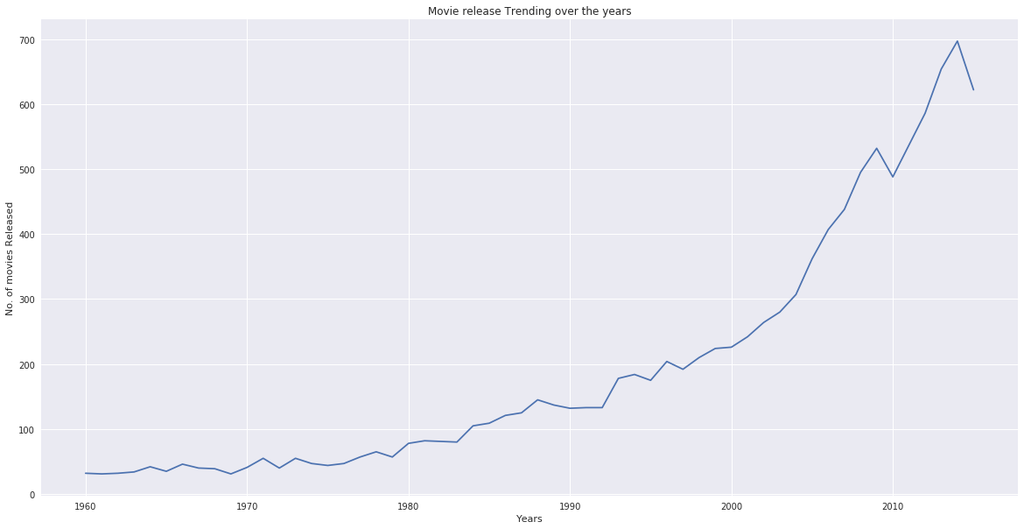

```python
moviesperyear = df_movie['release_year'].value_counts().sort_index();
moviesperyear.head(3)
plt.plot(moviesperyear)
plt.title("Movie release Trending over the years")
plt.xlabel("Years")
plt.ylabel("No. of movies Released")
moviesperyear.tail(3)
```

Base on above the plot,we can conclude that year 2014 year has the highest release of movies (697) followed by year 2013 (654) and year 2015 (622).

```python
moviesperyear.idxmax(), moviesperyear.idxmin()
```

```
(2014, 1961)
```

### Research Question 4 : which Movie have highest and lowest revenue values.

```python
#we used HighLow function
HighLow('revenue')
```

```
Highest revenue :  Avatar
Lowset revenue :  Shattered Glass
```

|  | 1386 | 5067 |
| --- | --- | --- |
| id | 19995 | 13537 |
| popularity | 9.43277 | 0.462609 |
| budget | 2.37e+08 | 6e+06 |
| revenue | 2.78151e+09 | 2 |
| original_title | Avatar | Shattered Glass |
| cast | Sam Worthington\|Zoe Saldana\|Sigourney Weaver\|S... | Hayden Christensen\|Peter Sarsgaard\|ChloÃ« Sevi... |
| director | James Cameron | Billy Ray |
| keywords | culture clash\|future\|space war\|space colony\|so... | NaN |
| runtime | 162 | 94 |
| genres | Action\|Adventure\|Fantasy\|Science Fiction | Drama\|History |
| production_companies | Ingenious Film Partners\|Twentieth Century Fox ... | Lions Gate Films\|Cruise/Wagner Productions\|Bau... |
| release_date | 12/10/09 | 11/14/03 |
| vote_count | 8458 | 46 |
| vote_average | 7.1 | 6.4 |
| release_year | 2009 | 2003 |
| profit | 2.54451e+09 | -6e+06 |

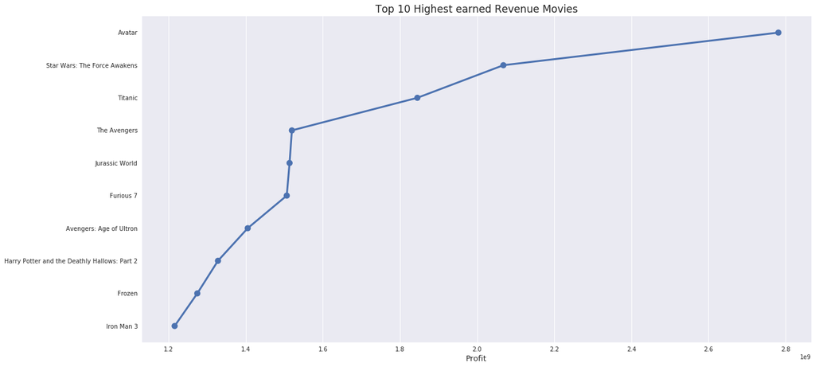

```python
data_revenue = pd.DataFrame(df_movie['revenue'].sort_values(ascending=False))
data_revenue['original_title'] = df_movie['original_title']
data = list(map(str,(data_revenue['original_title'])))
data
x = list(data[:10])
y = list(data_revenue['revenue'][:10])

axs = sns.pointplot(x=y,y=x)
sns.set(rc={'figure.figsize':(8,4)})
axs.set_title("Top 10 Highest earned Revenue Movies",fontsize = 17)
axs.set_xlabel("Profit",fontsize = 13)
sns.set_style("darkgrid")
```

Based on above chart shows the highest revenue made by Avatar and second column shows the lowest revenue movie by 'shattered glass' in this dataset. Avatar earn over 2.78B revenue in this dataset. And the movie which made lowest revenue is 'Shattered Glass'.

### Research Question 5: Movie with Longest And Shortest Runtime?

```python
HighLow('runtime')
```

```
Highest runtime :  The Story of Film: An Odyssey
Lowset runtime :  Batman: Strange Days
```

|  | 3894 | 1112 |
| --- | --- | --- |
| id | 125336 | 264170 |
| popularity | 0.006925 | 0.202776 |
| budget | NaN | NaN |
| revenue | NaN | NaN |
| original_title | The Story of Film: An Odyssey | Batman: Strange Days |
| cast | Mark Cousins\|Jean-Michel Frodon\|Cari Beauchamp... | Kevin Conroy\|Brian George\|Tara Strong |
| director | Mark Cousins | Bruce Timm |
| keywords | cinema\|nouvelle vague\|hindi cinema\|cinema novo... | dc comics\|superhero\|based on comic book\|noir\|p... |
| runtime | 900 | 3 |
| genres | Documentary | Action\|Animation |
| production_companies | NaN | DC Comics |
| release_date | 9/3/11 | 4/9/14 |
| vote_count | 14 | 20 |
| vote_average | 9.2 | 7.6 |
| release_year | 2011 | 2014 |
| profit | NaN | NaN |

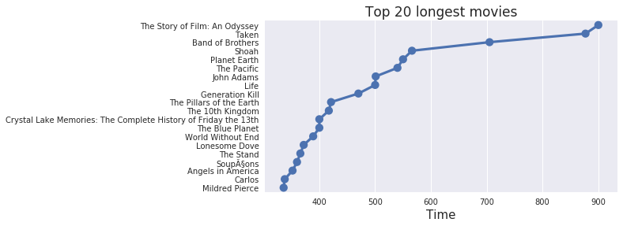

```python
data_runtime = pd.DataFrame(df_movie['runtime'].sort_values(ascending=False))
data_runtime['original_title'] = df_movie['original_title']
data = list(map(str,(data_runtime['original_title'])))
data
x = list(data[:20])
y = list(data_runtime['runtime'][:20])

axs = sns.pointplot(x=y,y=x)
sns.set(rc={'figure.figsize':(8,4)})
axs.set_title("Top 20 longest movies",fontsize = 17)
axs.set_xlabel("Time",fontsize = 15)
sns.set_style("darkgrid")
```

'The Story of Film: An Odyssey' movie has the highest runtime, Runtime of 900 min, This movie contain 6 or 7 parts that's why it is so long. The Shortest Movie 'Batmen : Strange Days' have 3 min runtime. its so shortest

### Research Question 6 : Which length movies most liked by the audiences according to their popularity?

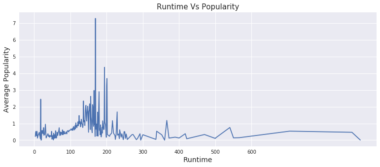

```python
df_movie.groupby('runtime')['popularity'].mean().plot(figsize = (13,5),xticks=np.arange(0,700,100))


plt.title("Runtime Vs Popularity",fontsize = 15)


plt.xlabel('Runtime',fontsize = 14)
plt.ylabel('Average Popularity',fontsize = 14)

sns.set(rc={'figure.figsize':(10,5)})
sns.set_style("whitegrid")
```

We observed that 120-200 runtime is more popular than long duration movie

### Research Question 7: Which year has the highest Profit Rate

```
Text(0,0.5,'Average Profit')
```

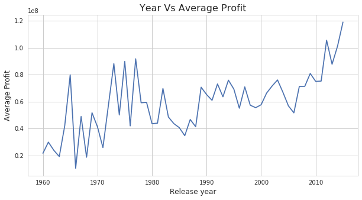

```python
df_movie.groupby('release_year')['profit'].mean().plot();
plt.title("Year Vs Average Profit",fontsize = 16);
plt.xlabel('Release year',fontsize = 12)
plt.ylabel('Average Profit',fontsize = 12)
```

### Research Question 8: How do budgets correlate with revenues? Do high budgets mean high revenues?

```python
#find the correlation between budget and revenues
cor1 = df_movie['budget']
cor2 = df_movie['revenue']
cor3 = cor1.corr(cor2)
cor3
```

```
0.68840319045227083
```

```python
# In budget and Revenue column have so many Null values thats why we will avoid to plot a scatter chart
df_corr=df_movie[(df_movie['budget']>0) & (df_movie['revenue']>0)]
df_corr.shape
```

```
(3849, 16)
```

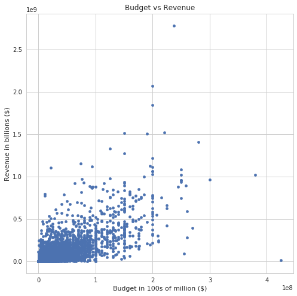

```python
df_corr.plot(x='budget',y='revenue',kind='scatter',figsize=(8,8));
plt.title('Budget vs Revenue')
plt.xlabel('Budget in 100s of million ($)');
plt.ylabel('Revenue in billions ($)');
```

In above scatter plot shows, there are so many outliers represent as Movies which have highest budget but lower revenue. and we found out the positive coorelation above. but there are so outliers shows which movie have highest budget does not mean it will earn high revenues

### Research Question 9: How do ratings correlate with profits?

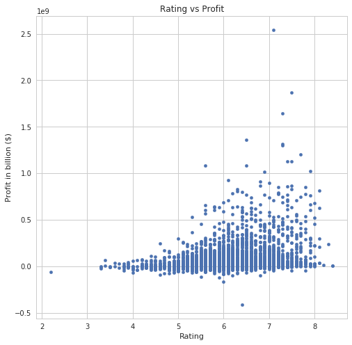

```python
df_movie['Profit']=df_movie['revenue']-df_movie['budget']
df_movie.plot(x='vote_average',y='Profit',kind='scatter',figsize=(8,8));
plt.ylabel('Profit in billion ($)');
plt.xlabel('Rating');
plt.title('Rating vs Profit');
```

The vote_average and Profit have weak positive relation. This relationship implying that a high rating does not strongly correlate to high profits.

### Research Question 10: Which Genre Has The Highest Release Of Movies?

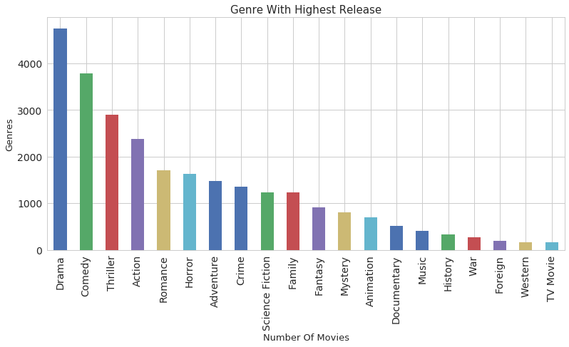

```python
# make a function whcih will use for split the string and return into two different row
def split_string(x):
    data_plot = df_movie[x].str.cat(sep = '|')
    data = pd.Series(data_plot.split('|'))
    info = data.value_counts(ascending=False)
    return info


genre_movies = split_string('genres')
genre_movies.plot(kind= 'bar',figsize = (13,6),fontsize=14)

plt.title("Genre With Highest Release",fontsize=15)
plt.xlabel('Number Of Movies',fontsize=13)
plt.ylabel("Genres",fontsize= 13)
sns.set_style("whitegrid")
```

Based on above Bar plot, we can see that Drama is most famous genre and its most film making in Drama genre(4700) AND OTHER IS comedy and thriller

### Research Question 11 : Top 10 Production Companies With Higher Number Of Release?

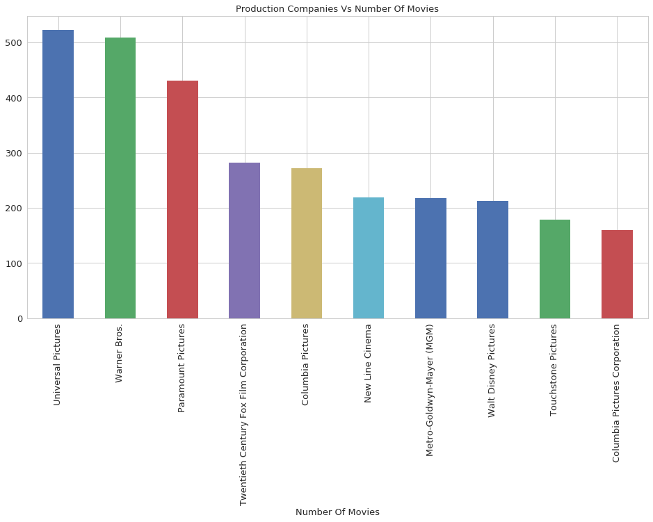

```python
ProductionCompanies = split_string('production_companies')

#plot he barh plot
ProductionCompanies.iloc[:10].plot(kind='bar',figsize=(16,8),fontsize=13)
plt.title("Production Companies Vs Number Of Movies",fontsize=13)
plt.xlabel('Number Of Movies',fontsize=13)
sns.set_style("whitegrid")
```

## Submitting your Project

> Before you submit your project, you need to create a .html or .pdf version of this notebook in the workspace here. To do that, run the code cell below. If it worked correctly, you should get a return code of 0, and you should see the generated .html file in the workspace directory (click on the orange Jupyter icon in the upper left).

> Alternatively, you can download this report as .html via the **File** > **Download as** submenu, and then manually upload it into the workspace directory by clicking on the orange Jupyter icon in the upper left, then using the Upload button.

> Once you've done this, you can submit your project by clicking on the "Submit Project" button in the lower right here. This will create and submit a zip file with this .ipynb doc and the .html or .pdf version you created. Congratulations!

```python
from subprocess import call
call(['python', '-m', 'nbconvert', 'Investigate_a_Dataset.ipynb'])
```

```
0
```